# **Assignment 4: EICU-v2.0 database**

Student name: Phan Hoang An Nguyen

Student ID: 100404103

Dataset name: eICU Collaborative Research Database v2.0

Dataset source: The eICU Collaborative Research Database, a freely available multi-center database for critical care research. Pollard TJ, Johnson AEW, Raffa JD, Celi LA, Mark RG and Badawi O. Scientific Data (2018). DOI: 10.1038/sdata.2018.178. Available at: https://www.nature.com/articles/sdata2018178

**Objectives**

We tried to re-create the findings from the article below by using machine learning to build predictive model to predict the status of partient in first admission to the ICU:

- Peer review article as reference: Na Pattalung, T., Ingviya, T., & Chaichulee, S. (2021). Feature explanations in recurrent neural networks for predicting risk of mortality in intensive care patients. Journal of Personalized Medicine, 11(9), 934.
- Below is the ERD of table that were used for query

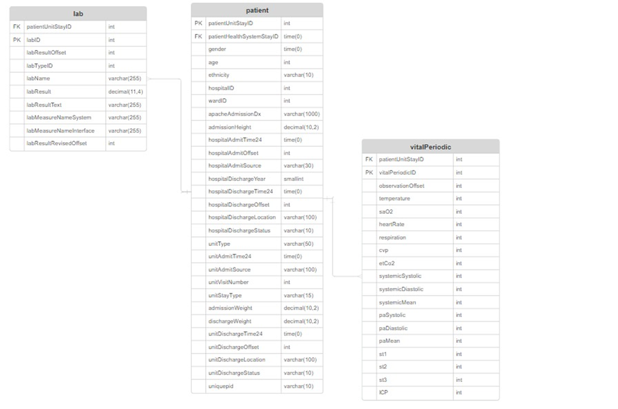

- Below is the workflow of SQL query step by step. Please refer to the txt file for SQL codes to extract data by Snowflake.

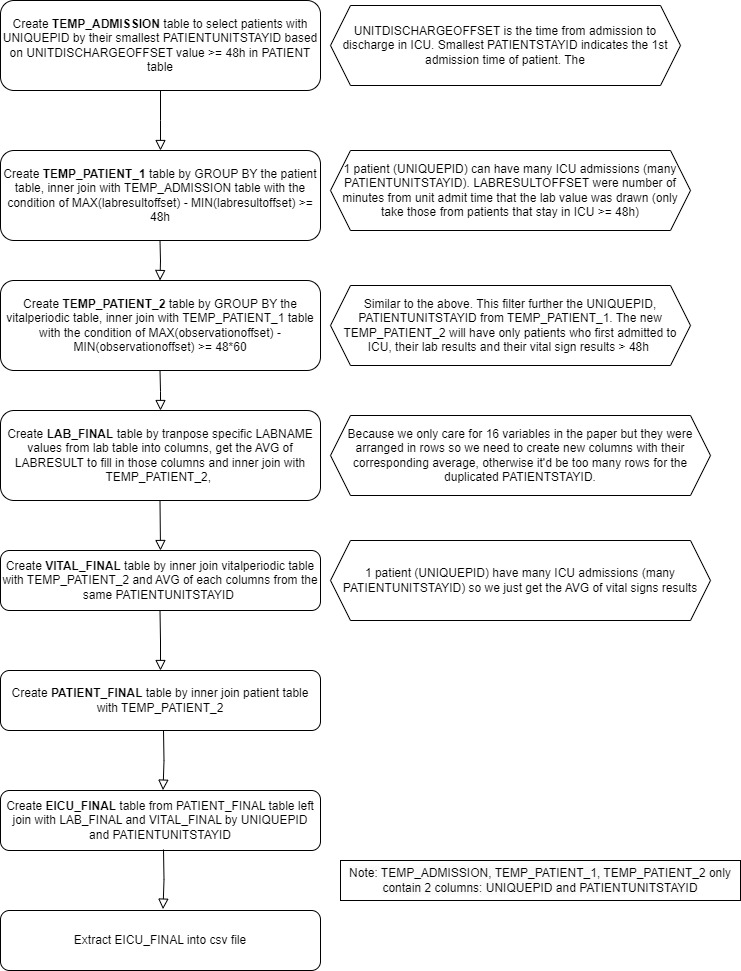

**Install and Import necessary libraries**

```python
# Import libraries
import pandas as pd
import numpy as np
import seaborn as sns #import Seaborn
from matplotlib import pyplot as plt
import lightgbm

from sklearn.datasets import make_classification
from sklearn.model_selection import RandomizedSearchCV
%matplotlib inline
```

```python
# Mount on GG Drive
from google.colab import drive
drive.mount('/content/drive')
```

# **Read the data**

```python
# Read the dataset
eicu = pd.read_csv("/content/drive/MyDrive/CPSC4830/data/EICU_final.csv")
eicu.head()
```

|  | PATIENTUNITSTAYID | UNIQUEPID | GENDER | AGE | ETHNICITY | ADMISSIONHEIGHT | UNITTYPE | ADMISSIONWEIGHT | DISCHARGEWEIGHT | UNITDISCHARGEOFFSET | ... | CHLORIDE | CREATININE | GLUCOSE | HEMOGLOBIN | HEMATOCRIT | PLATELET_COUNT | POTASSIUM | PARTIAL_THROMBOPLASTIN_TIME | SODIUM | WHITE_BLOOD_CELLS |
| --- | --- | --- | --- | --- | --- | --- | --- | --- | --- | --- | --- | --- | --- | --- | --- | --- | --- | --- | --- | --- | --- |
| 0 | 2689995 | 027-175937 | Male | 82 | Caucasian | 182.0 | Med-Surg ICU | 85.9 | NaN | 3106 | ... | 100.833333 | 1.050000 | NaN | 9.300000 | 27.100000 | 128.333333 | 4.033333 | 31.400000 | 133.500000 | 4.783333 |
| 1 | 2767053 | 027-175941 | Male | 65 | African American | 175.0 | CCU-CTICU | 78.7 | NaN | 35933 | ... | 111.857143 | 2.758571 | 138.476191 | 8.852632 | 28.305263 | 274.266667 | 3.560000 | 32.600000 | 142.730769 | 12.166667 |
| 2 | 2733600 | 027-175948 | Male | 52 | Caucasian | 185.4 | Med-Surg ICU | 94.3 | NaN | 3280 | ... | 109.000000 | 0.676000 | 99.200000 | 10.485714 | 33.885714 | 262.000000 | 3.640000 | 41.540000 | 141.800000 | 5.600000 |
| 3 | 2793093 | 027-17600 | Female | 79 | Asian | 162.6 | Med-Surg ICU | 59.0 | NaN | 14040 | ... | 104.533333 | 0.372667 | 144.933333 | 10.816667 | 35.408333 | 229.833333 | 3.850000 | NaN | 138.733333 | 17.000000 |
| 4 | 2684032 | 027-176071 | Male | 76 | Caucasian | 167.6 | CSICU | 69.1 | NaN | 32061 | ... | 99.581395 | 1.188636 | 136.209302 | 11.552778 | 33.688889 | 146.250000 | 3.899029 | 42.589189 | 132.679012 | 9.555556 |

5 rows × 34 columns

# EDA

```python
# Structure of dataset
eicu.info()
```

```
<class 'pandas.core.frame.DataFrame'>
RangeIndex: 49898 entries, 0 to 49897
Data columns (total 34 columns):
 #   Column                       Non-Null Count  Dtype
---  ------                       --------------  -----
 0   PATIENTUNITSTAYID            49898 non-null  int64
 1   UNIQUEPID                    49898 non-null  object
 2   GENDER                       49896 non-null  object
 3   AGE                          49898 non-null  object
 4   ETHNICITY                    49396 non-null  object
 5   ADMISSIONHEIGHT              49599 non-null  float64
 6   UNITTYPE                     49898 non-null  object
 7   ADMISSIONWEIGHT              48862 non-null  float64
 8   DISCHARGEWEIGHT              29787 non-null  float64
 9   UNITDISCHARGEOFFSET          49898 non-null  int64
```

[output cut: 26 more lines]

```python
# Shape of dataset
eicu.shape
```

```
(49898, 34)
```

- It's different with the reference paper (the author had 36,283 rows while mine was 49,898 rows)

```python
eicu.iloc[:,2:].describe()
```

|  | ADMISSIONHEIGHT | ADMISSIONWEIGHT | DISCHARGEWEIGHT | UNITDISCHARGEOFFSET | TEMPERATURE | SATURATE_OXYGEN | HEARTRATE | RESPIRATION | DIASTOLIC | MEAN_ARTERIAL | ... | CHLORIDE | CREATININE | GLUCOSE | HEMOGLOBIN | HEMATOCRIT | PLATELET_COUNT | POTASSIUM | PARTIAL_THROMBOPLASTIN_TIME | SODIUM | WHITE_BLOOD_CELLS |
| --- | --- | --- | --- | --- | --- | --- | --- | --- | --- | --- | --- | --- | --- | --- | --- | --- | --- | --- | --- | --- | --- |
| count | 49599.000000 | 48862.000000 | 29787.000000 | 49898.000000 | 8856.000000 | 49531.000000 | 49871.000000 | 46797.000000 | 17799.000000 | 17924.000000 | ... | 49843.000000 | 49826.000000 | 49732.000000 | 49771.000000 | 49797.000000 | 49489.000000 | 49856.000000 | 30649.000000 | 49853.000000 | 49762.000000 |
| mean | 169.271468 | 84.465473 | 85.112800 | 7976.094112 | 38.508346 | 96.555561 | 85.684713 | 20.120281 | 60.359277 | 81.142197 | ... | 104.045540 | 1.447318 | 139.233862 | 10.692688 | 32.463747 | 210.761636 | 4.017734 | 37.934891 | 138.755990 | 11.627835 |
| std | 13.456920 | 27.396213 | 27.556193 | 8442.224122 | 9.515490 | 2.050517 | 13.946768 | 4.489837 | 13.489065 | 17.993579 | ... | 5.586228 | 1.402581 | 44.022645 | 1.972124 | 5.775452 | 95.622961 | 0.407399 | 16.093354 | 4.385433 | 6.504618 |
| min | 0.000000 | 0.000000 | 0.000000 | 2880.000000 | 0.000000 | 30.360676 | 0.000000 | 0.000000 | -50.000000 | -50.000000 | ... | 73.000000 | 0.097500 | 31.000000 | 3.978947 | 14.284211 | 2.363636 | 1.800000 | 15.000000 | 106.500000 | 0.000000 |
| 25% | 162.500000 | 66.700000 | 67.100000 | 4005.000000 | 36.737755 | 95.424486 | 75.714764 | 17.180741 | 53.231319 | 72.993350 | ... | 100.800000 | 0.736364 | 111.000000 | 9.136754 | 27.966667 | 148.000000 | 3.747332 | 28.000000 | 136.333333 | 8.300000 |
| 50% | 170.000000 | 80.200000 | 81.700000 | 5496.000000 | 37.179651 | 96.733161 | 85.162890 | 19.615291 | 59.356457 | 79.482259 | ... | 104.166667 | 0.992857 | 127.750000 | 10.420000 | 31.718182 | 199.000000 | 3.970000 | 32.666667 | 138.750000 | 10.679286 |
| 75% | 177.800000 | 97.520000 | 98.900000 | 8733.750000 | 37.575454 | 97.939787 | 95.051259 | 22.470935 | 66.397374 | 87.579411 | ... | 107.426786 | 1.525650 | 154.777778 | 12.023810 | 36.371429 | 258.600000 | 4.240000 | 41.600000 | 141.200000 | 13.728571 |
| max | 605.000000 | 953.000000 | 328.200000 | 729176.000000 | 103.000000 | 100.000000 | 155.000819 | 148.778926 | 368.000000 | 357.000000 | ... | 150.833333 | 29.207000 | 1336.000000 | 22.350000 | 66.000000 | 2642.250000 | 7.900000 | 207.800000 | 178.529412 | 395.125000 |

8 rows × 27 columns

```python
# Column names
eicu.columns
```

```
Index(['PATIENTUNITSTAYID', 'UNIQUEPID', 'GENDER', 'AGE', 'ETHNICITY',
       'ADMISSIONHEIGHT', 'UNITTYPE', 'ADMISSIONWEIGHT', 'DISCHARGEWEIGHT',
       'UNITDISCHARGEOFFSET', 'UNITDISCHARGESTATUS', 'TEMPERATURE',
       'SATURATE_OXYGEN', 'HEARTRATE', 'RESPIRATION', 'DIASTOLIC',
       'MEAN_ARTERIAL', 'SYSTOLIC', 'ALBUMIN', 'BLOOD_UREA_NITROGEN',
       'BILIRUBIN', 'LACTATE', 'BICARBONATE', 'BAND_NEUTROPHIL', 'CHLORIDE',
       'CREATININE', 'GLUCOSE', 'HEMOGLOBIN', 'HEMATOCRIT', 'PLATELET_COUNT',
       'POTASSIUM', 'PARTIAL_THROMBOPLASTIN_TIME', 'SODIUM',
       'WHITE_BLOOD_CELLS'],
      dtype='object')
```

**Our taget feature is UNITDISCHARGESTATUS.**

# Remove invalid values

- Age column should be integer or float but here is object. There must be something wrong

```python
# Check unique values of AGE
eicu['AGE'].unique()
```

```
array(['82', '65', '52', '79', '76', '74', '> 89', '57', '67', '37', '78',
       '71', '77', '80', '89', '50', '60', '54', '68', '63', '62', '19',
       '75', '86', '46', '56', '26', '69', '51', '61', '83', '34', '66',
       '53', '72', '64', '81', '48', '32', '88', '40', '18', '70', '73',
       '58', '85', '27', '44', '59', '84', '55', '42', '33', '87', '39',
       '45', '36', '28', '22', '47', '30', '29', '35', '49', '24', '25',
       '23', '43', '21', '31', '17', '38', '20', '41', '15', '16', '14',
       '11', '5', '2', '1'], dtype=object)
```

```python
# Replace the value
eicu['AGE'] = eicu['AGE'].replace('> 89', 89)
```

```python
# Change type of AGE to integer
eicu['AGE'] = eicu['AGE'].astype(int)
```

- Because we don't want when we perform imputation later, the algorithm will take invalid values into account
- Below values were taken from the research paper

```python
# Define the valid range of values
bounds = {
    'AGE': (0, 100),
    'ADMISSIONHEIGHT': (0, 270),
    'ADMISSIONWEIGHT': (0, 300),
    'DISCHARGEWEIGHT': (0, 300),
    'TEMPERATURE': (26, 45),
    'SATURATE_OXYGEN': (0, 100),
    'HEARTRATE': (0, 350),
    'RESPIRATION': (0, 300),
    'DIASTOLIC': (0, 375),
    'MEAN_ARTERIAL': (14, 330),
    'SYSTOLIC': (0, 375),
    'ALBUMIN': (0.6, 6),
    'BLOOD_UREA_NITROGEN': (0, 250),
    'BILIRUBIN': (0.1, 60),
    'LACTATE': (0.4, 30),
    'BICARBONATE': (0, 60),
    'BAND_NEUTROPHIL': (0, 100),
    'CHLORIDE': (50, 175),
    'CREATININE': (0.1, 60),
    'GLUCOSE': (33, 2000),
    'HEMOGLOBIN': (0, 25),
    'HEMATOCRIT': (0, 75),
    'PLATELET_COUNT': (0, 2000),
    'POTASSIUM': (0, 12),
    'PARTIAL_THROMBOPLASTIN_TIME': (18.8, 150),
    'SODIUM': (50, 225),
    'WHITE_BLOOD_CELLS': (0, 1000)
}
```

```python
# Remove outliers, ignore the missing values
eicu_no_outlier = eicu.copy()
for column, (lower, upper) in bounds.items():
    if lower is not None and upper is not None:
        eicu_no_outlier = eicu_no_outlier[(eicu_no_outlier[column] > lower) | (eicu_no_outlier[column].isna())]
        eicu_no_outlier = eicu_no_outlier[(eicu_no_outlier[column] < upper) | (eicu_no_outlier[column].isna())]
```

```python
# Check the shape before and after removal
eicu.shape, eicu_no_outlier.shape
```

```
((49898, 34), (48955, 34))
```

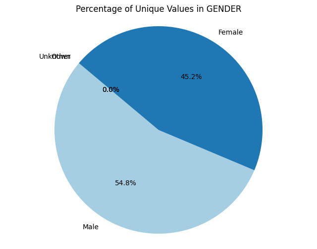

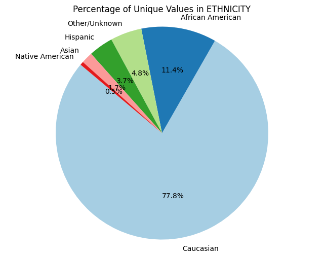

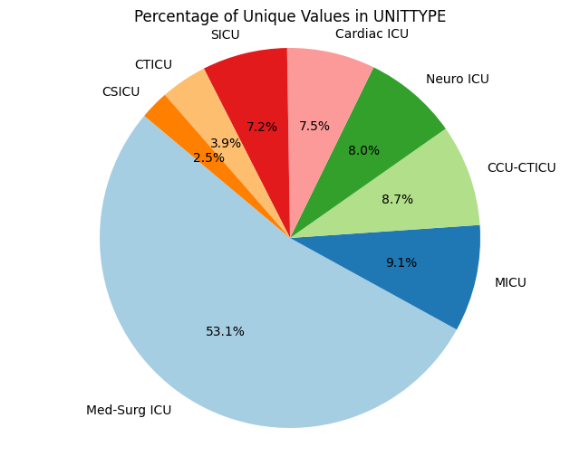

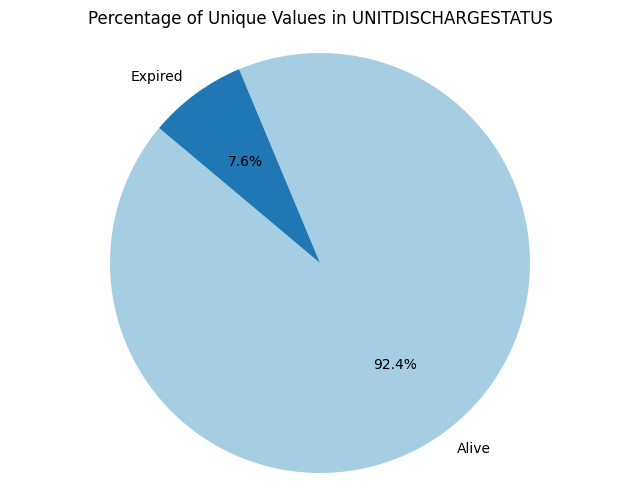

```python
# Plot the pie charts for % of unique values in cat_data
eicu_cat = ['GENDER','ETHNICITY','UNITTYPE','UNITDISCHARGESTATUS']

for column in eicu_cat:
    unique_counts = eicu[column].value_counts(normalize=True) * 100
    plt.figure(figsize=(8, 6))
    plt.pie(unique_counts, labels=unique_counts.index, autopct='%1.1f%%', startangle=140, colors=plt.cm.Paired(range(len(unique_counts))))
    plt.title(f'Percentage of Unique Values in {column}')
    plt.axis('equal')  # Equal aspect ratio ensures that pie is drawn as a circle.
    plt.show()
```

- Highly imbalance in target variable UNITDISCHARGESTATUS --> might need UNDERSAMPLING later

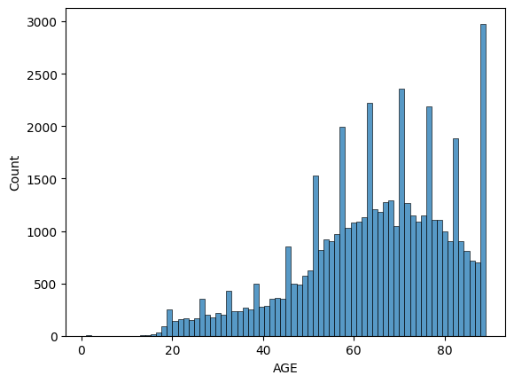

```python
# Plot distribution of AGE column
sns.histplot(eicu['AGE'])
```

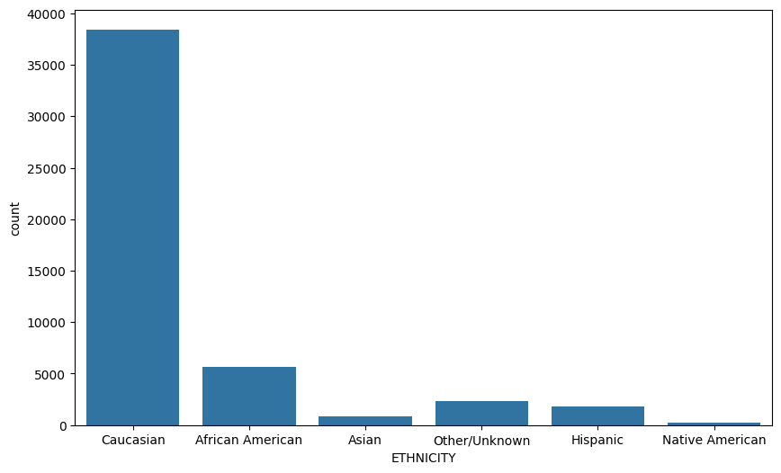

```python
# Plot ETHNICITY column
plt.figure(figsize=(10, 6))
sns.countplot(x='ETHNICITY',data=eicu)
plt.show()
```

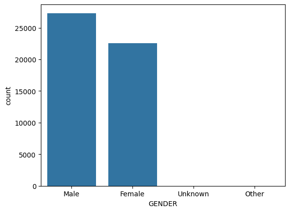

```python
# Plot Gender column
sns.countplot(x='GENDER',data=eicu)
```

- More patients at older age admitted to ICU
- Male and Female ratio are comparable
- Most patients were Caucasian. Might be due to the fact that the data was collected at hospitals in America

# **Cleaning data**

- Usually by the rules of thumb, we can't impute values of columns that have missing values over 50% otherwise it'd affect the distribution of variables and introduce considerable bias so it's best to drop them

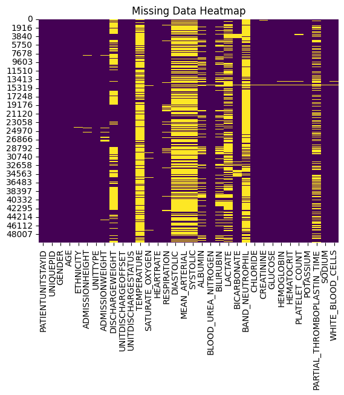

```python
# Plot heatmap to show the distribution of missing values
sns.heatmap(eicu_no_outlier.isnull(), cbar=False, cmap='viridis')
plt.title('Missing Data Heatmap')
plt.show()
```

```python
# Count missing values for each column
missing_counts = eicu_no_outlier.iloc[:,2:].isnull().sum()

# Get percentage of missing values for each column
missing_percentages = (missing_counts / len(eicu_no_outlier)) * 100

# Combine counts and percentages into a DataFrame
missing_info = pd.DataFrame({
    'Missing Count': missing_counts,
    'Missing Percentage': missing_percentages
})

# Sort the DataFrame by 'Missing Percentage' in ascending order
missing_info_sorted = missing_info.sort_values(by='Missing Percentage', ascending=False)
print(missing_info_sorted)
```

```
                             Missing Count  Missing Percentage
TEMPERATURE                          40425           82.575835
BAND_NEUTROPHIL                      38702           79.056276
DIASTOLIC                            31487           64.318251
SYSTOLIC                             31486           64.316209
MEAN_ARTERIAL                        31429           64.199775
LACTATE                              24077           49.181902
DISCHARGEWEIGHT                      19651           40.140946
PARTIAL_THROMBOPLASTIN_TIME          18924           38.655908
BILIRUBIN                            10130           20.692473
ALBUMIN                               8092           16.529466
RESPIRATION                           3025            6.179144
BICARBONATE                           2481            5.067920
ADMISSIONWEIGHT                       1030            2.103973
ETHNICITY                              494            1.009090
PLATELET_COUNT                         404            0.825248
SATURATE_OXYGEN                        360            0.735369
ADMISSIONHEIGHT                        297            0.606680
GLUCOSE                                166            0.339087
WHITE_BLOOD_CELLS                      135            0.275763
HEMOGLOBIN                             127            0.259422
HEMATOCRIT                             101            0.206312
CREATININE                              72            0.147074
BLOOD_UREA_NITROGEN                     62            0.126647
CHLORIDE                                54            0.110305
SODIUM                                  44            0.089878
POTASSIUM                               42            0.085793
HEARTRATE                               27            0.055153
UNITDISCHARGESTATUS                      4            0.008171
GENDER                                   2            0.004085
AGE                                      0            0.000000
UNITDISCHARGEOFFSET                      0            0.000000
UNITTYPE                                 0            0.000000
```

There are many missing values so data cleaning is required. Most of the missing values came from Vital signs and Lab tests features. Theoretically, there are 3 types of missing data, we need to understand which features above that have what type of missing data. If possible, it's better to have MCAR than the other 2.

1. Missing Completely at Random (MCAR): The missingness has no relationship with any values, observed or unobserved.
2. Missing at Random (MAR): The missingness is related to some of the observed data but not the missing data itself.
3. Missing Not at Random (MNAR): The missingness is related to the value of the missing data itself.

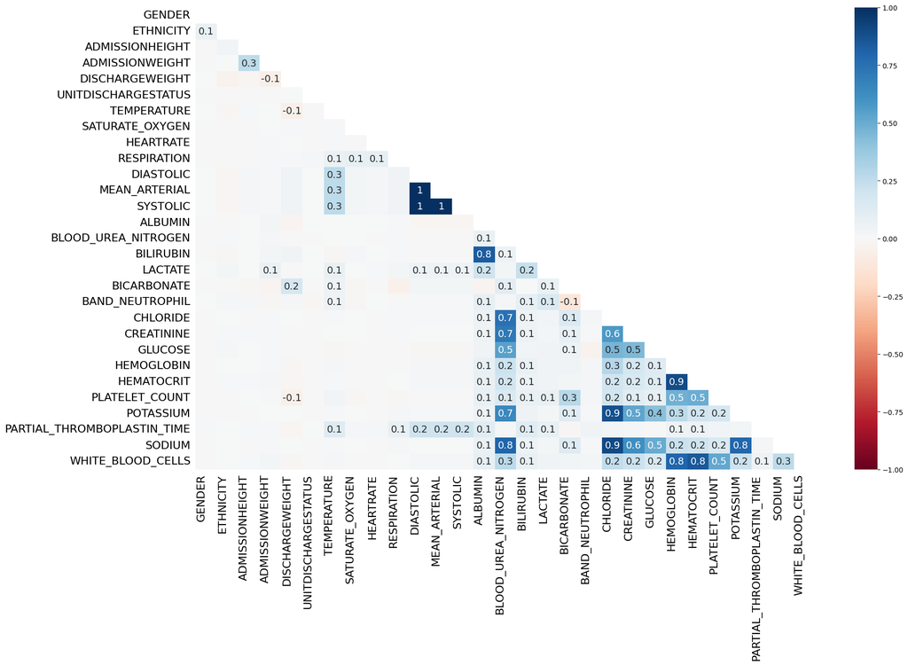

```python
# Plot heatmap to check correlation of missing values of 1 feature to others
import missingno as msno
import statsmodels.api as sm
msno.heatmap(eicu_no_outlier)
plt.xticks(rotation=90)
plt.show()
```

```python
correlation_matrix = eicu_no_outlier.isnull().corr().abs()
high_correlation_pairs = [(correlation_matrix.columns[i], correlation_matrix.columns[j])
                          for i in range(len(correlation_matrix.columns))
                          for j in range(i+1, len(correlation_matrix.columns))
                          if correlation_matrix.iloc[i, j] > 0.8]
print("High correlation pairs: \n", high_correlation_pairs)
```

```
High correlation pairs:
 [('DIASTOLIC', 'MEAN_ARTERIAL'), ('DIASTOLIC', 'SYSTOLIC'), ('MEAN_ARTERIAL', 'SYSTOLIC'), ('ALBUMIN', 'BILIRUBIN'), ('BLOOD_UREA_NITROGEN', 'SODIUM'), ('CHLORIDE', 'POTASSIUM'), ('CHLORIDE', 'SODIUM'), ('HEMOGLOBIN', 'HEMATOCRIT'), ('HEMOGLOBIN', 'WHITE_BLOOD_CELLS'), ('HEMATOCRIT', 'WHITE_BLOOD_C…
```

- Base on the correlation matrix and heatmap of missing value above, we can see some features had missing values CORRELATED with other features in the dataset. The higher the value, the stronger correlation.

```python
# Check number of missing value TEMPERATURE and DISCHARGESTATUS
print('Number of missing value from Temp to Expired patient: ', eicu_no_outlier[eicu_no_outlier['UNITDISCHARGESTATUS']=='Expired']['TEMPERATURE'].isnull().sum())
print('Number of missing value from Temp to Alive patient: ', eicu_no_outlier[eicu_no_outlier['UNITDISCHARGESTATUS']=='Alive']['TEMPERATURE'].isnull().sum())
```

```
Number of missing value from Temp to Expired patient:  2593
Number of missing value from Temp to Alive patient:  37829
```

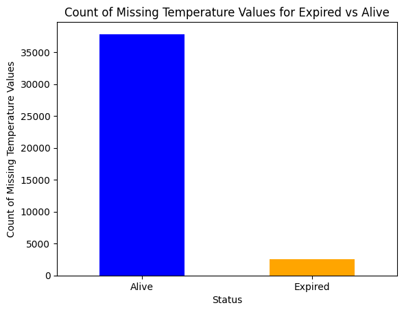

```python
missing_counts = eicu_no_outlier[eicu_no_outlier['TEMPERATURE'].isna()]['UNITDISCHARGESTATUS'].value_counts()

# Plotting the bar chart
missing_counts.plot(kind='bar', color=['blue', 'orange'])
plt.xlabel('Status')
plt.ylabel('Count of Missing Temperature Values')
plt.title('Count of Missing Temperature Values for Expired vs Alive')
plt.xticks(rotation=0)
plt.show()
```

```python
# Check number of missing value BAND_NEUTROPHIL and DISCHARGESTATUS
print('Number of missing value from Temp to Expired patient: ', eicu_no_outlier[eicu_no_outlier['UNITDISCHARGESTATUS']=='Expired']['BAND_NEUTROPHIL'].isnull().sum())
print('Number of missing value from Temp to Alive patient: ', eicu_no_outlier[eicu_no_outlier['UNITDISCHARGESTATUS']=='Alive']['BAND_NEUTROPHIL'].isnull().sum())
```

```
Number of missing value from Temp to Expired patient:  2449
Number of missing value from Temp to Alive patient:  36252
```

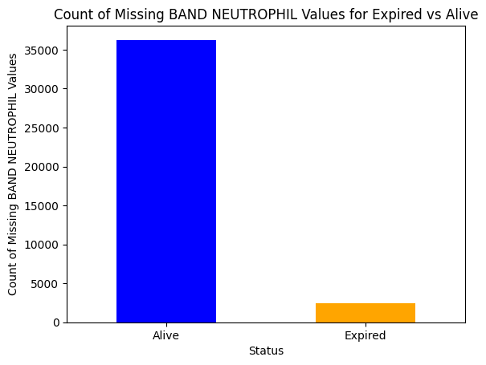

```python
missing_counts = eicu_no_outlier[eicu_no_outlier['BAND_NEUTROPHIL'].isna()]['UNITDISCHARGESTATUS'].value_counts()

# Plotting the bar chart
missing_counts.plot(kind='bar', color=['blue', 'orange'])
plt.xlabel('Status')
plt.ylabel('Count of Missing BAND NEUTROPHIL Values')
plt.title('Count of Missing BAND NEUTROPHIL Values for Expired vs Alive')
plt.xticks(rotation=0)
plt.show()
```

- TEMPRATURE and BAND_NEUTROPHIL column might have MAR in this case since it doesn't depend on the status of discharged patients so we can omit the possibility of no data due to not being alive. They don't have any correlation with other features, plus the missing % are very high (79% and 82%) --> drop them

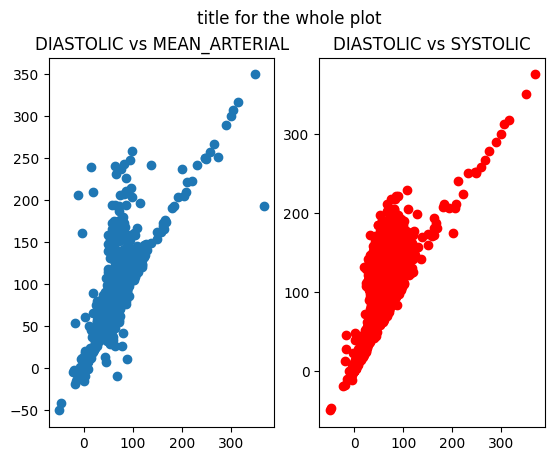

```python
# Scatterplot of DIASTOLIC vs MEAN_ARTERIAL and SYSTOLIC
plt.subplot(1, 2, 1)
plt.scatter(np.array(eicu['DIASTOLIC']), np.array(eicu['MEAN_ARTERIAL'])) # default color is blue
plt.title("DIASTOLIC vs MEAN_ARTERIAL")

plt.subplot(1, 2, 2)
plt.scatter(np.array(eicu['DIASTOLIC']), np.array(eicu['SYSTOLIC']), color='red') # r for red color
plt.title("DIASTOLIC vs SYSTOLIC")

plt.suptitle("title for the whole plot")
plt.show()
```

- DIASTOLIC missing values are positive, correlated strongly with MEAN_ARTERIAL and SYSTOLIC so there's a chance of MNAR here. All 3 columns have high missing values ~64% so regardless of which imputation techniques (linear regression, kNN, IterativeImputer, etc.), it'll seriously mess up the distribution of my final predictive model --> drop all 3 columns

```python
# Drop columns
eicu_clean = eicu_no_outlier.drop(columns=['TEMPERATURE','BAND_NEUTROPHIL', 'DIASTOLIC', 'MEAN_ARTERIAL', 'SYSTOLIC'])
```

- There are still features that have missing values correlated with each other but the missing % are smaller than 50% so we impute them

# Missing data imputation

- BILIRUBIN and ALBUMIN missing values are strongly correlated as well but they only miss ~20% so I can use IterativeImputer to handle the imputation of multiple columns with missing values by iteratively using regression models in this case because imputation by linear regression cannot compute when both columns have missing data

```python
# Impute missing values in 'BILIRUBIN', 'ALBUMIN' columns by IterativeImputer
from sklearn.experimental import enable_iterative_imputer
from sklearn.impute import IterativeImputer

columns_to_impute = ['BILIRUBIN', 'ALBUMIN']

# Initialize IterativeImputer
imputer = IterativeImputer(max_iter=10, random_state=0)

# Fit and transform the data
eicu_imputed = pd.DataFrame(imputer.fit_transform(eicu_clean[columns_to_impute]), columns=columns_to_impute)

# Replace the original columns with the imputed values
eicu_clean[columns_to_impute] = eicu_imputed

# Check missing values
print('Number of missing data in BILIRUBIN: ', eicu_clean['BILIRUBIN'].isnull().sum())
print('Number of missing data in ALBUMIN: ', eicu_clean['ALBUMIN'].isnull().sum())
```

```
Number of missing data in BILIRUBIN:  939
Number of missing data in ALBUMIN:  939
```

```python
# Drop rows that having missing data in "UNITDISCHARGESTATUS" column
eicu_clean = eicu_clean.dropna(subset=['UNITDISCHARGESTATUS'])
print('Number of missing data in target feature: ', eicu_clean['UNITDISCHARGESTATUS'].isnull().sum())
```

```
Number of missing data in target feature:  0
```

```python
eicu_clean.shape
```

```
(48951, 29)
```

```python
# Count number of unique value
eicu_clean['PATIENTUNITSTAYID'].nunique()
```

```
48951
```

```python
# Count number of unique value
eicu_clean['UNIQUEPID'].nunique()
```

```
48951
```

- Since PATIENTSTAYID and UNIQUEPID are unique and irrelevant to the prediction of our target variable --> drop them

```python
# Drop the first and second column from df because PATIENTSTAYID and UNIQUEPID are unique and irrelevant to our model
eicu_clean = eicu_clean.iloc[:, 2:]
```

```python
# Split the dataset to categorical and numerical columns
cat_col = ['GENDER','ETHNICITY','UNITTYPE','UNITDISCHARGESTATUS']

# Create the first DataFrame with the specified columns
cat_data = eicu_clean[cat_col]

# Create the second DataFrame with the rest of the columns
num_data = eicu_clean.drop(columns=cat_col)
```

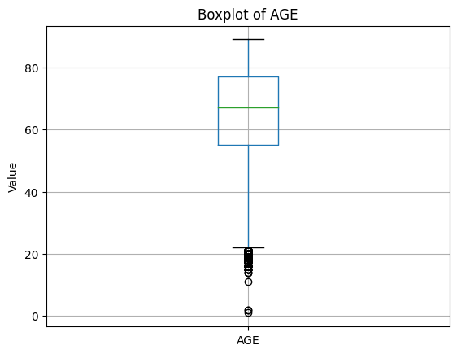

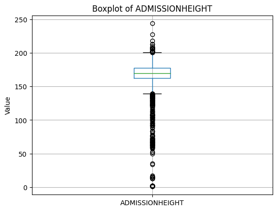

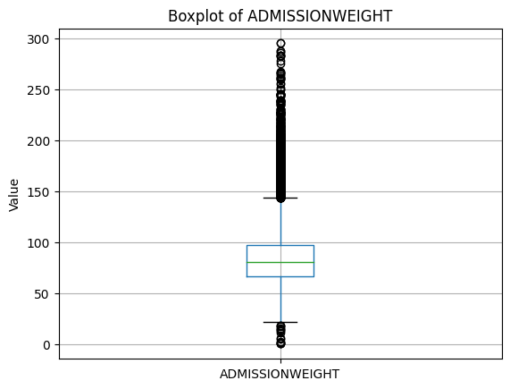

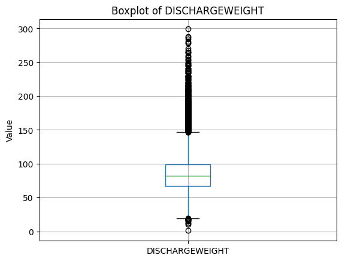

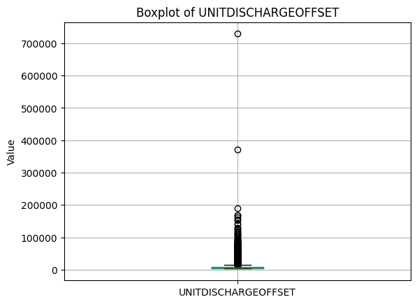

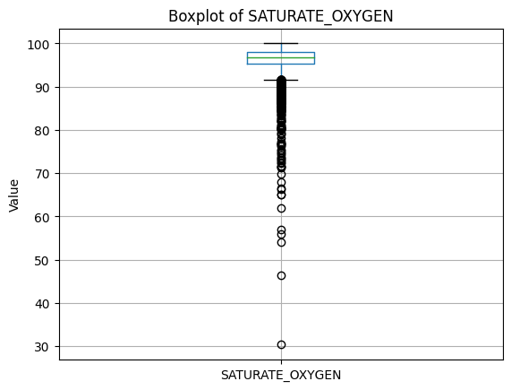

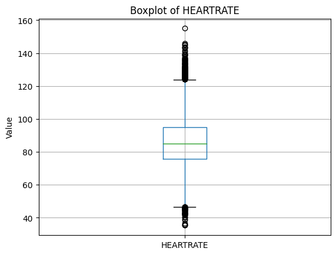

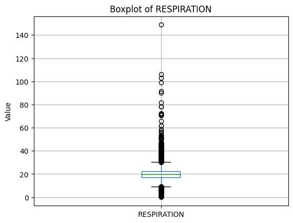

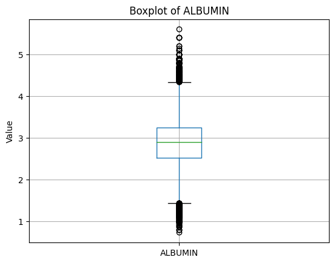

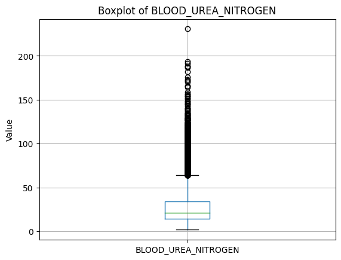

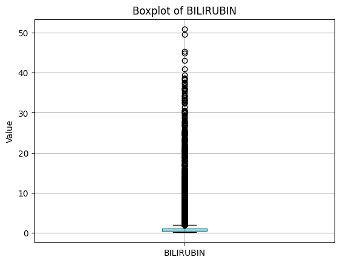

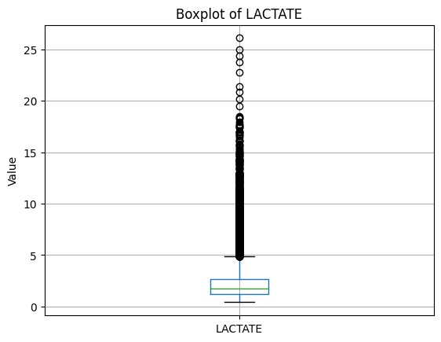

[11 more figures not shown]

```python
# Check for outliers again before imputing numerical data
for column in num_data.columns:
    plt.figure()
    num_data.boxplot(column=column)
    plt.title(f'Boxplot of {column}')
    plt.ylabel('Value')
    plt.show()
```

- The purpose of querying the DISCHARGEWEIGHT was to compare with ADMISSIONWEIGHT but since it's missing 40% (probably due to taking weight and height measurement for admission only) --> drop it
- UNITDISCHARGEOFFSET showed the time of discharged for the patients but here is not time series data anymore because the vital + lab signs were from average --> drop it

```python
# Drop columns
num_data = num_data.drop(columns=['UNITDISCHARGEOFFSET','DISCHARGEWEIGHT'])
```

- Even though the boxplot showed outliers for some features but they are all within valid range, plus these were the extreme case of admitting to the ICU so we couldn't remove those --> Impute the rest of numerical data by kNN method

```python
from sklearn.impute import KNNImputer
# Apply kNN imputer
imputer = KNNImputer(n_neighbors=5)
num_data_imputed = pd.DataFrame(imputer.fit_transform(num_data), columns=num_data.columns)
```

```python
# Concatenate cat_data and num_data_imputed to form final df
eicu_final = pd.concat([cat_data, num_data_imputed], axis=1)
eicu_final.head()
```

|  | GENDER | ETHNICITY | UNITTYPE | UNITDISCHARGESTATUS | AGE | ADMISSIONHEIGHT | ADMISSIONWEIGHT | SATURATE_OXYGEN | HEARTRATE | RESPIRATION | ... | CHLORIDE | CREATININE | GLUCOSE | HEMOGLOBIN | HEMATOCRIT | PLATELET_COUNT | POTASSIUM | PARTIAL_THROMBOPLASTIN_TIME | SODIUM | WHITE_BLOOD_CELLS |
| --- | --- | --- | --- | --- | --- | --- | --- | --- | --- | --- | --- | --- | --- | --- | --- | --- | --- | --- | --- | --- | --- |
| 0 | Male | Caucasian | Med-Surg ICU | Alive | 82.0 | 182.0 | 85.9 | 98.734959 | 87.431341 | 16.589661 | ... | 100.833333 | 1.050000 | 137.757070 | 9.300000 | 27.100000 | 128.333333 | 4.033333 | 31.400000 | 133.500000 | 4.783333 |
| 1 | Male | African American | CCU-CTICU | Alive | 65.0 | 175.0 | 78.7 | 99.232744 | 89.778104 | 24.227967 | ... | 111.857143 | 2.758571 | 138.476191 | 8.852632 | 28.305263 | 274.266667 | 3.560000 | 32.600000 | 142.730769 | 12.166667 |
| 2 | Male | Caucasian | Med-Surg ICU | Alive | 52.0 | 185.4 | 94.3 | 96.387218 | 74.011725 | 12.341709 | ... | 109.000000 | 0.676000 | 99.200000 | 10.485714 | 33.885714 | 262.000000 | 3.640000 | 41.540000 | 141.800000 | 5.600000 |
| 4 | Male | Caucasian | CSICU | Alive | 74.0 | 175.3 | 74.6 | 97.690798 | 75.663133 | 17.128783 | ... | 93.625000 | 9.188750 | 142.000000 | 9.072727 | 27.809091 | 163.700000 | 4.090909 | 33.000000 | 133.500000 | 12.630000 |
| 5 | Male | Caucasian | CSICU | Alive | 89.0 | 170.0 | 80.3 | 97.638021 | 78.447402 | 22.064639 | ... | 104.750000 | 1.000000 | 118.000000 | 8.200000 | 24.400000 | 203.000000 | 4.057143 | 80.742857 | 135.200000 | 11.825000 |

5 rows × 25 columns

- There should be some missing rows left since we didn't perform imputation for categorical data but we expect the missing data is not much

```python
# Show column names and number of missing data
# Count missing values for each column
missing_counts = eicu_final.isnull().sum()

# Get percentage of missing values for each column
missing_percentages = (missing_counts / len(eicu_final)) * 100

# Combine counts and percentages into a DataFrame
missing_info = pd.DataFrame({
    'Missing Count': missing_counts,
    'Missing Percentage': missing_percentages
})

# Sort the DataFrame by 'Missing Percentage' in ascending order
missing_info_sorted = missing_info.sort_values(by='Missing Percentage', ascending=False)
print(missing_info_sorted)
```

```
                             Missing Count  Missing Percentage
ETHNICITY                             1437            2.880106
GENDER                                 945            1.894015
LACTATE                                943            1.890007
SODIUM                                 943            1.890007
PARTIAL_THROMBOPLASTIN_TIME            943            1.890007
POTASSIUM                              943            1.890007
PLATELET_COUNT                         943            1.890007
HEMATOCRIT                             943            1.890007
HEMOGLOBIN                             943            1.890007
GLUCOSE                                943            1.890007
CREATININE                             943            1.890007
CHLORIDE                               943            1.890007
BICARBONATE                            943            1.890007
BILIRUBIN                              943            1.890007
BLOOD_UREA_NITROGEN                    943            1.890007
ALBUMIN                                943            1.890007
RESPIRATION                            943            1.890007
HEARTRATE                              943            1.890007
SATURATE_OXYGEN                        943            1.890007
ADMISSIONWEIGHT                        943            1.890007
ADMISSIONHEIGHT                        943            1.890007
AGE                                    943            1.890007
UNITDISCHARGESTATUS                    943            1.890007
UNITTYPE                               943            1.890007
WHITE_BLOOD_CELLS                      943            1.890007
```

```python
# Replace missing values of EUTHNICITY as Other/Unknown
eicu_final['ETHNICITY'] = eicu_final['ETHNICITY'].fillna('Other/Unknown')
```

- Since the missing data only makes up for less than 2%. We drop rows that have null value

```python
# Drop rows that have missing data from df
eicu_final = eicu_final.dropna()
```

```python
# Check the final df
eicu_final.isnull().sum()
```

```
GENDER                         0
ETHNICITY                      0
UNITTYPE                       0
UNITDISCHARGESTATUS            0
AGE                            0
ADMISSIONHEIGHT                0
ADMISSIONWEIGHT                0
SATURATE_OXYGEN                0
HEARTRATE                      0
RESPIRATION                    0
ALBUMIN                        0
BLOOD_UREA_NITROGEN            0
BILIRUBIN                      0
LACTATE                        0
BICARBONATE                    0
CHLORIDE                       0
CREATININE                     0
GLUCOSE                        0
HEMOGLOBIN                     0
HEMATOCRIT                     0
PLATELET_COUNT                 0
POTASSIUM                      0
PARTIAL_THROMBOPLASTIN_TIME    0
SODIUM                         0
WHITE_BLOOD_CELLS              0
dtype: int64
```

# Split data

- Transform categorical data into numerical

```python
# Split the dataset to categorical and numerical columns
cat_col = ['GENDER','ETHNICITY','UNITTYPE','UNITDISCHARGESTATUS']

# Create the first DataFrame with the specified columns
cat_data = eicu_final[cat_col]

# Create the second DataFrame with the rest of the columns
num_data = eicu_final.drop(columns=cat_col)
```

```python
from sklearn.preprocessing import LabelEncoder
# Convert categorical data into numerical data
LE = LabelEncoder()

for i in cat_data:
  cat_data[i] = LE.fit_transform(cat_data[i])
```

```python
# Concat cat_data and num_data
eicu_final = pd.concat([cat_data, num_data], axis=1)
eicu_final.head()
```

|  | GENDER | ETHNICITY | UNITTYPE | UNITDISCHARGESTATUS | AGE | ADMISSIONHEIGHT | ADMISSIONWEIGHT | SATURATE_OXYGEN | HEARTRATE | RESPIRATION | ... | CHLORIDE | CREATININE | GLUCOSE | HEMOGLOBIN | HEMATOCRIT | PLATELET_COUNT | POTASSIUM | PARTIAL_THROMBOPLASTIN_TIME | SODIUM | WHITE_BLOOD_CELLS |
| --- | --- | --- | --- | --- | --- | --- | --- | --- | --- | --- | --- | --- | --- | --- | --- | --- | --- | --- | --- | --- | --- |
| 0 | 1 | 2 | 5 | 0 | 82.0 | 182.0 | 85.9 | 98.734959 | 87.431341 | 16.589661 | ... | 100.833333 | 1.050000 | 137.757070 | 9.300000 | 27.100000 | 128.333333 | 4.033333 | 31.400000 | 133.500000 | 4.783333 |
| 1 | 1 | 0 | 0 | 0 | 65.0 | 175.0 | 78.7 | 99.232744 | 89.778104 | 24.227967 | ... | 111.857143 | 2.758571 | 138.476191 | 8.852632 | 28.305263 | 274.266667 | 3.560000 | 32.600000 | 142.730769 | 12.166667 |
| 2 | 1 | 2 | 5 | 0 | 52.0 | 185.4 | 94.3 | 96.387218 | 74.011725 | 12.341709 | ... | 109.000000 | 0.676000 | 99.200000 | 10.485714 | 33.885714 | 262.000000 | 3.640000 | 41.540000 | 141.800000 | 5.600000 |
| 4 | 1 | 2 | 1 | 0 | 74.0 | 175.3 | 74.6 | 97.690798 | 75.663133 | 17.128783 | ... | 93.625000 | 9.188750 | 142.000000 | 9.072727 | 27.809091 | 163.700000 | 4.090909 | 33.000000 | 133.500000 | 12.630000 |
| 5 | 1 | 2 | 1 | 0 | 89.0 | 170.0 | 80.3 | 97.638021 | 78.447402 | 22.064639 | ... | 104.750000 | 1.000000 | 118.000000 | 8.200000 | 24.400000 | 203.000000 | 4.057143 | 80.742857 | 135.200000 | 11.825000 |

5 rows × 25 columns

```python
# Define X and y
X,y = eicu_final.drop('UNITDISCHARGESTATUS',axis=1), eicu_final['UNITDISCHARGESTATUS']
```

```python
X.head()
```

|  | GENDER | ETHNICITY | UNITTYPE | AGE | ADMISSIONHEIGHT | ADMISSIONWEIGHT | SATURATE_OXYGEN | HEARTRATE | RESPIRATION | ALBUMIN | ... | CHLORIDE | CREATININE | GLUCOSE | HEMOGLOBIN | HEMATOCRIT | PLATELET_COUNT | POTASSIUM | PARTIAL_THROMBOPLASTIN_TIME | SODIUM | WHITE_BLOOD_CELLS |
| --- | --- | --- | --- | --- | --- | --- | --- | --- | --- | --- | --- | --- | --- | --- | --- | --- | --- | --- | --- | --- | --- |
| 0 | 1 | 2 | 5 | 82.0 | 182.0 | 85.9 | 98.734959 | 87.431341 | 16.589661 | 3.400000 | ... | 100.833333 | 1.050000 | 137.757070 | 9.300000 | 27.100000 | 128.333333 | 4.033333 | 31.400000 | 133.500000 | 4.783333 |
| 1 | 1 | 0 | 0 | 65.0 | 175.0 | 78.7 | 99.232744 | 89.778104 | 24.227967 | 1.981818 | ... | 111.857143 | 2.758571 | 138.476191 | 8.852632 | 28.305263 | 274.266667 | 3.560000 | 32.600000 | 142.730769 | 12.166667 |
| 2 | 1 | 2 | 5 | 52.0 | 185.4 | 94.3 | 96.387218 | 74.011725 | 12.341709 | 3.400000 | ... | 109.000000 | 0.676000 | 99.200000 | 10.485714 | 33.885714 | 262.000000 | 3.640000 | 41.540000 | 141.800000 | 5.600000 |
| 4 | 1 | 2 | 1 | 74.0 | 175.3 | 74.6 | 97.690798 | 75.663133 | 17.128783 | 2.893794 | ... | 93.625000 | 9.188750 | 142.000000 | 9.072727 | 27.809091 | 163.700000 | 4.090909 | 33.000000 | 133.500000 | 12.630000 |
| 5 | 1 | 2 | 1 | 89.0 | 170.0 | 80.3 | 97.638021 | 78.447402 | 22.064639 | 2.600000 | ... | 104.750000 | 1.000000 | 118.000000 | 8.200000 | 24.400000 | 203.000000 | 4.057143 | 80.742857 | 135.200000 | 11.825000 |

5 rows × 24 columns

```python
y.value_counts() # 0=Alive, 1=Expired
```

```
UNITDISCHARGESTATUS
0    44381
1     3625
Name: count, dtype: int64
```

```python
X.shape, y.shape
```

```
((48006, 24), (48006,))
```

# Standardize value

```python
from sklearn.preprocessing import StandardScaler

scaler = StandardScaler()
X_scaled = scaler.fit_transform(X)
```

# LDA (Linear Discriminant Analysis) as Feature Reduction

- LDA transforms the original features into a new lower-dimensional space. The new features are linear combinations of the original features, and these combinations are chosen to maximize class separability while projecting the data onto a subspace with fewer dimensions (components), where the separation between different classes is maximized. The new dimensions are created based on the data's class information

```python
from sklearn.discriminant_analysis import LinearDiscriminantAnalysis as LDA
from sklearn.ensemble import RandomForestClassifier
from sklearn.model_selection import train_test_split, cross_val_score
from sklearn.metrics import accuracy_score
from imblearn.under_sampling import RandomUnderSampler
```

```python
# Determine the best number of components
max_components = min(len(X.columns), len(set(y)) - 1)
best_score = 0
best_n_components = 0

for n in range(1, max_components + 1):
    lda = LDA(n_components=n)
    scores = cross_val_score(lda, X_scaled, y, cv=5, scoring='accuracy')
    mean_score = scores.mean()
    print(f"n_components = {n}, Accuracy = {mean_score}")

    if mean_score > best_score:
        best_score = mean_score
        best_n_components = n

print(f"Best n_components = {best_n_components}, Best Accuracy = {best_score}")
```

```
n_components = 1, Accuracy = 0.9244886054599126
Best n_components = 1, Best Accuracy = 0.9244886054599126
```

```python
# Transform data by LDA based on CV best result above
lda = LDA(n_components=1)
X_lda = lda.fit_transform(X_scaled, y)
```

- By applying LDA, we were able to reduce dimension of our data from 24 to 1

# Undersampling using Near miss

```python
y.value_counts() # 0=Alive, 1=Expired
```

```
UNITDISCHARGESTATUS
0    44381
1     3625
Name: count, dtype: int64
```

- Since we have imbalance data in target variable, we decided to prioritize Recall over Precision because we aim to minimize False Negatives (= patients who might Expired (y=1) but predicted as Alive (y=0))

```python
from imblearn.under_sampling import RandomUnderSampler, NearMiss
from collections import Counter
```

```python
# Under sample the majority class
nearmiss = NearMiss(version=3)
X_lda_nearmiss, y_nearmiss= nearmiss.fit_resample(X_lda, y)

# Check the number of records after over sampling
print(sorted(Counter(y_nearmiss).items()))
```

```
[(0, 3625), (1, 3625)]
```

# Split the data into train and test set

```python
from sklearn.model_selection import train_test_split
X_train, X_test, y_train, y_test = train_test_split(X_lda_nearmiss, y_nearmiss, test_size=0.3, random_state=42)
```

```python
X_train.shape, X_test.shape, y_train.shape, y_test.shape
```

```
((5075, 1), (2175, 1), (5075,), (2175,))
```

# Fit into RandomForest model

```python
# Train Random Forest
rf = RandomForestClassifier(n_estimators=100, random_state=42)
rf.fit(X_train, y_train)

# Predict on the test set
y_pred = rf.predict(X_test)
```

```python
# Evaluate the model
accuracy = accuracy_score(y_test, y_pred)
print(f"Accuracy: {accuracy}")

# Cross-validation
scores = cross_val_score(rf, X_train, y_train, cv=5, scoring='accuracy')
print(f"Cross-validated accuracy: {scores.mean()}")
```

```
Accuracy: 0.5806896551724138
Cross-validated accuracy: 0.5867980295566502
```

```python
from sklearn.metrics import classification_report, confusion_matrix
print('Classification report of LDA on RF:\n',classification_report(y_test,y_pred))
```

```
              precision    recall  f1-score   support

           0       0.60      0.53      0.56      1104
           1       0.57      0.63      0.60      1071

    accuracy                           0.58      2175
   macro avg       0.58      0.58      0.58      2175
weighted avg       0.58      0.58      0.58      2175
```

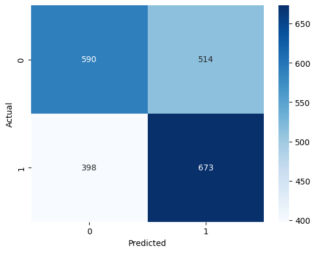

```python
# Plot confusion matrix by seaborn
sns.heatmap(confusion_matrix(y_test, y_pred), annot=True, fmt='d', cmap='Blues')
plt.xlabel('Predicted')
plt.ylabel('Actual')
plt.title('Confusion matrix of LDA on RF:\n')
plt.show()
```

# SelectKBest as Feature Selection technique

- Feature selection method in the sklearn library that selects the top k features based on univariate statistical tests. It helps in reducing the dimensionality of the dataset by selecting the most relevant features. The method works by scoring each feature using a specific scoring function and then selecting the features with the highest scores.
- Scoring: Each feature is scored individually based on its relationship with the target variable. Various scoring functions can be used, depending on the nature of the data
- Here we use f_classif = ANOVA F-value between label/feature for classification tasks

```python
# Standardize
scaler = StandardScaler()
X_scaled = scaler.fit_transform(X)

# Undersample the data using NearMiss-3
nearmiss = NearMiss(version=3)
X_res, y_res = nearmiss.fit_resample(X_scaled, y)
```

[output not shown]

```python
# Determine which k value is the best
from sklearn.feature_selection import SelectKBest, f_classif

max_features = X.shape[1]
accuracies = []
range_k = [1,5,10,15,20,24]

for k in range_k:
    selector = SelectKBest(score_func=f_classif, k=k)
    X_selected = selector.fit_transform(X_res, y_res)
    rf = RandomForestClassifier(n_estimators=100, random_state=42)
    scores = cross_val_score(rf, X_selected, y_res, cv=5, scoring='accuracy')
    mean_score = scores.mean()
    accuracies.append(mean_score)
    print(f"k = {k}, Accuracy = {mean_score}")
```

```
k = 1, Accuracy = 0.5146206896551724
k = 5, Accuracy = 0.5478620689655173
k = 10, Accuracy = 0.555448275862069
k = 15, Accuracy = 0.5662068965517242
k = 20, Accuracy = 0.5746206896551723
k = 24, Accuracy = 0.5750344827586206
```

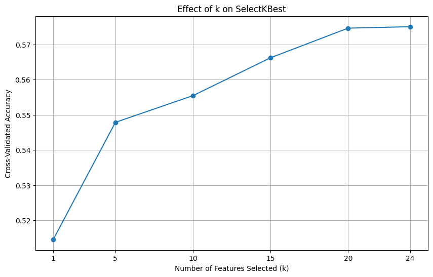

```python
# Plot the results
plt.figure(figsize=(10, 6))
plt.plot(range_k, accuracies, marker='o')
plt.title('Effect of k on SelectKBest')
plt.xlabel('Number of Features Selected (k)')
plt.ylabel('Cross-Validated Accuracy')
plt.xticks(range_k)
plt.grid(True)
plt.show()
```

```python
from sklearn.feature_selection import SelectKBest, f_classif

# Apply SelectKBest for feature selection
k = 20  # Select the number of features you want to keep
selector = SelectKBest(score_func=f_classif, k=k)
X_selected = selector.fit_transform(X_res, y_res)

# Get the selected feature names
mask = selector.get_support()
selected_features = X.columns[mask]
print("Selected features:", selected_features)
```

```
Selected features: Index(['ETHNICITY', 'UNITTYPE', 'AGE', 'ADMISSIONHEIGHT', 'ADMISSIONWEIGHT',
       'SATURATE_OXYGEN', 'HEARTRATE', 'RESPIRATION', 'BLOOD_UREA_NITROGEN',
       'BILIRUBIN', 'LACTATE', 'BICARBONATE', 'CHLORIDE', 'CREATININE',
       'GLUCOSE', 'HEMOGLOBIN', 'HEMATOCRIT', 'POTASSIUM',
       'PARTIAL_THROMBOPLASTIN_TIME', 'WHITE_BLOOD_CELLS'],
      dtype='object')
```

```python
from sklearn.model_selection import train_test_split
X_train, X_test, y_train, y_test = train_test_split(X_selected, y_res, test_size=0.3, random_state=42)
```

```python
# Train Random Forest
rf = RandomForestClassifier(n_estimators=100, random_state=42)
rf.fit(X_train, y_train)

# Predict on the test set
y_pred = rf.predict(X_test)
```

```python
from sklearn.metrics import classification_report, confusion_matrix
print('Classification report of SelectKBest on RF:\n',classification_report(y_test,y_pred))
```

```
Classification report of SelectKBest on RF:
               precision    recall  f1-score   support

           0       0.60      0.68      0.64      1104
           1       0.62      0.54      0.58      1071

    accuracy                           0.61      2175
   macro avg       0.61      0.61      0.61      2175
weighted avg       0.61      0.61      0.61      2175
```

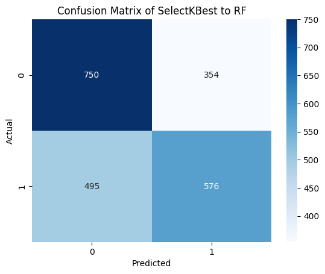

```python
# Plot confusion matrix by seaborn
sns.heatmap(confusion_matrix(y_test, y_pred), annot=True, fmt='d', cmap='Blues')
plt.xlabel('Predicted')
plt.ylabel('Actual')
plt.title('Confusion Matrix of SelectKBest to RF')
plt.show()
```

# Summary